# hw1

Shweta Singhal

February 14, 2016

Ans 1.a) Exponential family has the probability distribution given as:
$$P(x|\eta)=h(x)exp(\eta.T(x)-A(\eta))$$
$$E[T(X)|\eta]=\bigtriangledown A(\eta)$$

Also we know that sum of all the probabilities are 1, we can write this as :
$$\int\limits_{-\infty}^{+\infty}p (x)dx=1$$
$$\int\limits h(x)exp(\eta.T(x)-A(\eta))dx=1$$
taking derivative both sides
$$\frac{\partial}{\partial \eta} \int h(x)exp(\eta.T(x))dx = \frac{\partial}{\partial\eta} exp(A(\eta))$$
$$\frac{\int T(x)h(x)exp(\eta.T(x))dx}{exp(A(\eta))} = \grave A(\eta)$$
Using the equation:
$$E[g(x)] = \int g(x)P(x)dx$$
$$f(x) = h(x)exp(\eta.T(x) - A(\eta))$$
Hence we get,
$$E[T(x)] = (\grave A(\eta))$$

2. Exponential family can be written as :
   $$X\sim N(\mu,\sigma^2)$$
   $$P(x|\mu) = \frac{1}{\sqrt(2 \pi \sigma^2)}exp(\frac{-(x-\mu)^2}{2\sigma^2})$$
   $$P(x|\mu) = \frac{1}{\sqrt(2 \pi\sigma^2)}exp(\frac{-(\mu^2+2x\mu+x^2)}{2\sigma^2})$$

Here from the above equation,
$$h(x) = \frac{1}{\sqrt(2\pi)}exp(\frac{-x^2}{2\sigma^2})$$
$$\eta(\mu) = \mu$$
$$T(x) = \frac{x}{\sigma^2}$$
$$A(\sigma) = -\frac{\mu^2}{2\sigma^2} - log \sigma$$
$$(\grave A(\mu)) = \frac{\mu}{2\sigma^2}$$
$$E[T(x)] = \frac{\mu}{2\sigma^2}$$
$$(A'(\mu)) = E[T(x)]$$
Hence Proved.

Ans.2

$$P(X;\lambda)=(\lambda^k exp(-\lambda))/k!$$
(a)
$$=exp(ln(\lambda^k exp(-\lambda)))/k!$$
$$=exp((kln\lambda-\lambda))/k!$$
So Natural parameter is
$$\eta = ln\lambda$$

Sufficient statistics is
$$T(X=k) = k$$

2. Let one of the prior be Jeffery’s prior
   $$I(\lambda) = 1/k!*E[(\frac{d}{d\lambda}log(\lambda^k exp(-\lambda))^2]$$
   $$= 1/k!*E[(\frac{d}{d\lambda}(klog\lambda)-\lambda)^2]$$
   $$= E[\frac{k}{\lambda^2}]$$
   $$= 1/\lambda$$

So, Jeffery’s prior $P(\lambda) = \sqrt(I(\lambda))$
$$P(\lambda) = \sqrt(1/\lambda)$$

This is an improper prior, because its integral diverges.

$\textbf Posterior:$
$$P(\lambda|x_1,\ldots,x_n) = Gamma(\frac{1}{2} + \sum_{i=1}^{n}x_i, n)$$
Posterior is proper even though its prior is improper.

Another prior can be Uniform Prior-
$$p(\lambda)=c$$
where c is any constant, This prior is also improper prior.

$\textbf Posterior\ for\ Uniform \ Prior:$
$$P(\lambda|x_1,\ldots,x_n) = Gamma(\frac{1}{2} + \sum_{i=1}^{n}x_i, n)$$

Ans.3)
$$p(x_1,\ldots,x_n|\mu) = (\frac{1}{\sqrt(2\pi\sigma^2)})^n exp(\frac{-1}{2\sigma^2}\sum(x_i - \mu)^2)$$
Here mean is distributed with Uniform distribution:
$$\mu \sim Unif(a,b)$$
$$\implies p(\mu) = \frac{1}{b-a} \ \ \forall \mu \in [a,b]$$
$$p(\mu|x1,\ldots,x_n;\sigma^2,a,b) = \frac{p(x1,\ldots,x_n|\mu;\sigma^2,a,b)p(\mu)}{\int p(p(\mu|x1,\ldots,x_n;\sigma^2,a,b))p(\mu)d\mu}$$
$$p(\mu|x1,\ldots,x_n;\sigma^2,a,b) = \frac{(\frac{1}{\sqrt{2\pi\sigma^2}})^n exp(\frac{-1}{2\sigma^2}\sum(x_i - \mu)^2)\frac{1}{b-a}}{\frac{1}{b-a}(\frac{1}{\sqrt{2\pi\sigma^2}})^n \int_a^b exp(\frac{-1}{2\sigma^2}\sum(x_i - \mu)^2) d\mu}$$
Posterior PDF is also Normal Distribution.

Ans.4

```r
## Read in the cross-sectional OASIS data, including hippocampal volumes
x = read.csv("./oasis_cross-sectional.csv")
y = read.csv("./oasis_hippocampus.csv")
hippo = merge(x, y, by = "ID")
hippo = hippo[hippo$Age >= 60,]
hippo$Group[hippo$CDR == 0.0] = "Control"
hippo$Group[hippo$CDR == 0.5] = "Mild"
hippo$Group[hippo$CDR >= 1.0] = "Dementia"

def_mu_n <- function(lambda_0, mu_0, n, mean){
  mu = (lambda_0*mu_0 + n*mean)/(n+lambda_0)
  return(mu)
}

def_lambda_n <- function(n,lambda_0){
  lambda = n + lambda_0
  return(lambda)
}

def_alpha_n <- function(alpha_0, n){
  alpha = alpha_0 + (n/2.0)
  return(alpha)
}

def_beta_n <- function(beta_0, x_vec, mean, mu_0, n, lambda_0 ){
  beta = beta_0 + sum((x_vec-mean)^2)/2.0 + (n* lambda_0/(n+lambda_0))*((mean-mu_0)^2/2.0)
  return(beta)
}

#Sample sizes of the hippocampus data
n_1 = length(hippo$Group[hippo$CDR == 0.0])
n_2 = length(hippo$Group[hippo$CDR == 0.5])
n_3 = length(hippo$Group[hippo$CDR >= 1.0])

#Sample vector and their means
x1<- hippo$RightHippoVol[hippo$CDR == 0.0]
mean_1 = mean(x1)

x2<- hippo$RightHippoVol[hippo$CDR == 0.5]
mean_2 = mean(x2)

x3<- hippo$RightHippoVol[hippo$CDR >= 1.0]
mean_3 = mean(x3)

# Conjugate Prior parameters
lambda_0 = 10^(-6)
mu_0 = 0
alpha_0 = 10^(-6)
beta_0 = 10^(-6)
```

a.) As I have conjugate prior of Normal Inverse Gamma Distribution(N-IG Distribution), my join posterior distribution will also be N-IG distribution with hyper parameters calculated below:

```r
# j=1, Control
mu_1 = def_mu_n(lambda_0, mu_0,n_1, mean_1 )
lambda_1 = def_lambda_n(n_1, lambda_0)
alpha_1 = def_alpha_n(alpha_0, n_1)
beta_1 = def_beta_n(beta_0, x1, mean_1,mu_0, n_1, lambda_0)

# j=2, Mild
mu_2 = def_mu_n(lambda_0, mu_0,n_2, mean_2 )
lambda_2 = def_lambda_n(n_2, lambda_0)
alpha_2 = def_alpha_n(alpha_0, n_2)
beta_2 = def_beta_n(beta_0, x2, mean_2,mu_0, n_2, lambda_0)

# j=3, Dementia
mu_3 = def_mu_n(lambda_0, mu_0,n_3, mean_3 )
lambda_3 = def_lambda_n(n_3, lambda_0)
alpha_3 = def_alpha_n(alpha_0, n_3)
beta_3 = def_beta_n(beta_0, x3, mean_3,mu_0, n_3, lambda_0)
```

Marginal Posterior of $P(\sigma_j^2|y_{i,j}) \sim IG(alpha_n,beta_n)$

```r
#install the below given library which is used to get random samples from inverse gamma distribution
#install.packages("EDISON")
library("EDISON")
```

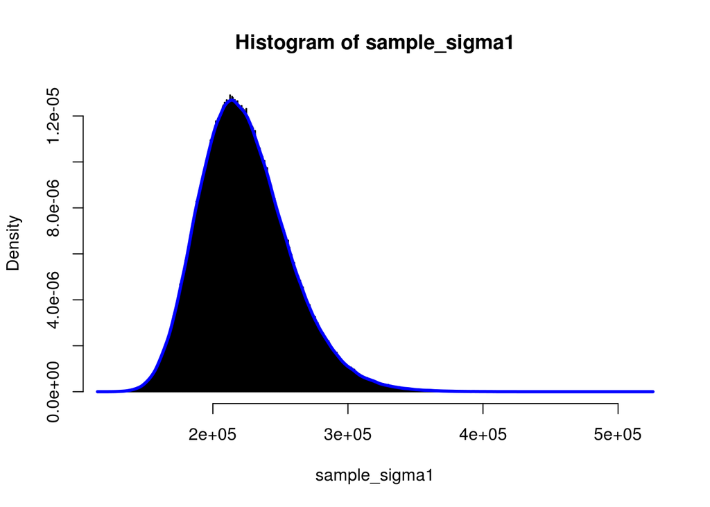

```r
#Samples from marginal posterior distribution of sigma^2|y
sample_sigma1 <- rinvgamma(10^6, alpha_1, beta_1)
hist(sample_sigma1, freq=FALSE, breaks = 1000)
lines(density(sample_sigma1),col="blue",lwd =3,xlab = expression(sigma^2))
```

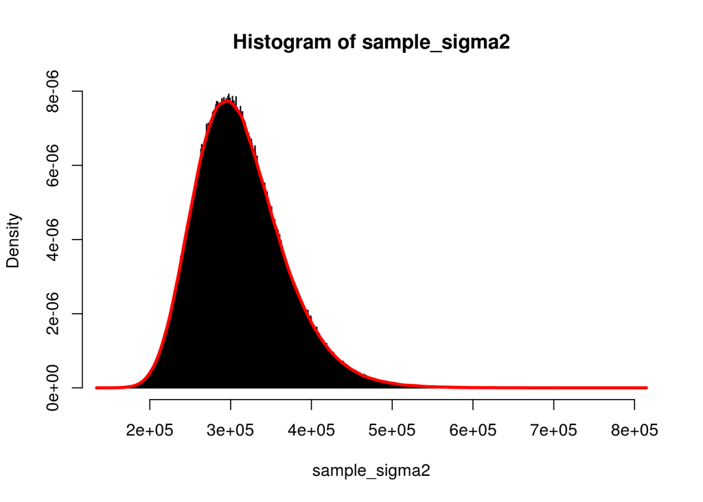

```r
sample_sigma2 <- rinvgamma(10^6, alpha_2, beta_2)
hist(sample_sigma2, freq=FALSE, breaks = 1000)
lines(density(sample_sigma2),col="red",lwd =3,xlab = expression(sigma^2))
```

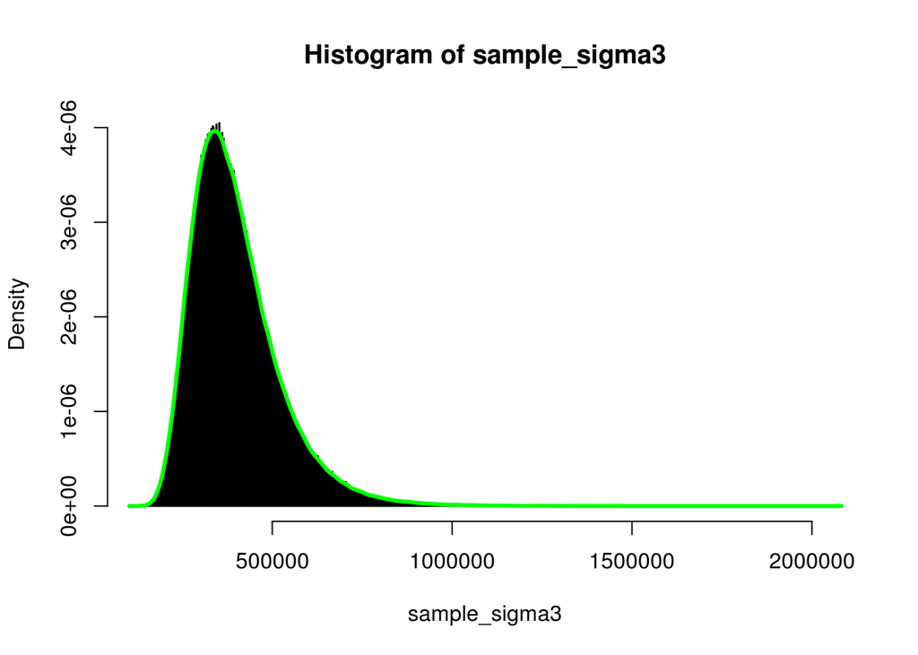

```r
sample_sigma3 <- rinvgamma(10^6, alpha_3, beta_3)
hist(sample_sigma3, freq=FALSE, breaks = 1000)
lines(density(sample_sigma3),col="green",lwd =3, xlab = expression(sigma^2))
```

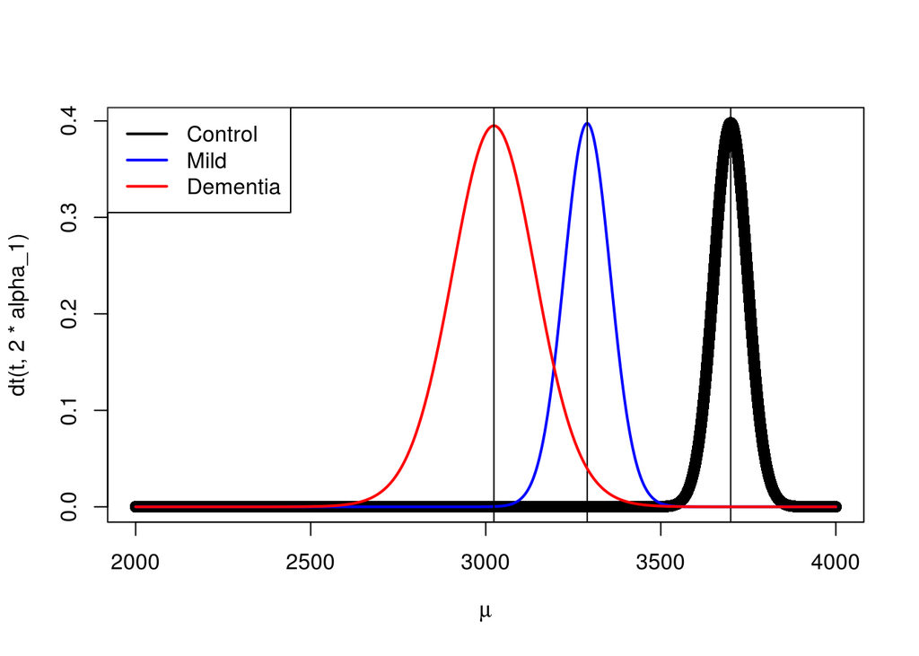

```r
mu_seq = seq(2000,4000, (2000/10^6))

#t-distribution for marginal probability of mu
t = sqrt(alpha_1*lambda_1/beta_1)*(mu_seq-mean_1)
plot(mu_seq,dt(t, 2*alpha_1), xlab = expression(mu))
abline(v = mean_1)

t2 = sqrt(alpha_2*lambda_2/beta_2)*(mu_seq-mean_2)
lines(mu_seq, dt(t2, 2*alpha_2), col= "blue",lwd =2, xlab = expression(mu))
abline(v = mean_2)

t3 = sqrt(alpha_3*lambda_3/beta_3)*(mu_seq-mean_3)
lines(mu_seq, dt(t3, 2*alpha_3), col= "red",lwd =2, xlab = expression(mu))
abline(v = mean_3)

legend('topleft', c("Control", "Mild", "Dementia"), col = c("black", "blue", "red"), lwd = 2)
```

Ans.4.c) Conditional density:
$$P(d_12|\sigma_1^2,\sigma_2^2,y_{i,j}) \sim N(\mu_1|\sigma_1^2) - N(\mu_2|\sigma_2^2)$$
So our, $d_12$ distribution will also be a normal distribution with $N(\mu,\sigma^2)$
$$\mu = \mu_1 - \mu_2$$
$$\sigma^2 = \frac{\sigma_1^2}{n_1} + \frac{\sigma_2^2}{n_2}$$

```r
sig_samp_1 <- rinvgamma(10^6, alpha_1, beta_1)
sig_samp_2 <- rinvgamma(10^6, alpha_2, beta_2)
sig_samp_3 <- rinvgamma(10^6, alpha_3, beta_3)

post_var_12 <- sqrt(sig_samp_1/n_1 + sig_samp_2/n_2)
post_var_13 <- sqrt(sig_samp_1/n_1 + sig_samp_3/n_3)
post_var_23 <- sqrt(sig_samp_2/n_2 + sig_samp_3/n_3)

post_mean_12 <- mu_1 - mu_2
post_mean_13 <- mu_1 - mu_3
post_mean_23 <- mu_2 - mu_3

d_12 <- rnorm(10^6,  post_mean_12, post_var_12)
d_13 <- rnorm(10^6,  post_mean_13, post_var_13)
d_23 <- rnorm(10^6,  post_mean_23, post_var_23)

n = 10^6
pdf_d12 = sum(d_12<0)/n
print(pdf_d12)
```

```
## [1] 3e-06
```

```r
pdf_d13 = sum(d_13<0)/n
print(pdf_d13)
```

```
## [1] 7e-06
```

```r
pdf_d23 = sum(d_23<0)/n
print(pdf_d23)
```

```
## [1] 0.031779
```

From the probabilities, we get that $P(d_12|y_{i,j})$ is almost $0$, which means $P(\mu_1<\mu_2|y_{i,j})$ is $0$. So we can say that the probabilities of $\mu_2$ being greater than $\mu_1$ is almost $0$.The same can be verified form the figure we have plotted in 4.b), where $\mu_1$ is mostly greater than $\mu_2$. Similiarly, we can compare $\mu_2$ and $\mu_3$, $\mu_2$ and $\mu_3$ has more overlapping in their graph, i.e, $P(\mu_2<\mu_3|y_{i,j})$ is relatively significant.

Ans.4.d)

```r
# one sided t-test for the difference between the two means \mu_1 & \mu_2
t.test(x1,x2,alternative = "greater" )
```

```
##
##  Welch Two Sample t-test
##
## data:  x1 and x2
## t = 4.9505, df = 129.41, p-value = 1.131e-06
## alternative hypothesis: true difference in means is greater than 0
## 95 percent confidence interval:
##  272.6944      Inf
## sample estimates:
## mean of x mean of y
##  3699.589  3289.735
```

```r
# one sided t-test for the difference between the two means \mu_1 & \mu_3
t.test(x1, x3, alternative = "greater" )
```

```
##
##  Welch Two Sample t-test
##
## data:  x1 and x3
## t = 5.0939, df = 31.693, p-value = 7.75e-06
## alternative hypothesis: true difference in means is greater than 0
## 95 percent confidence interval:
##  451.2974      Inf
## sample estimates:
## mean of x mean of y
##  3699.589  3023.360
```

```r
# one sided t-test for the difference between the two means \mu_2 & \mu_3
t.test(x2, x3, alternative = "greater" )
```

```
##
##  Welch Two Sample t-test
##
## data:  x2 and x3
## t = 1.8925, df = 39.069, p-value = 0.03293
## alternative hypothesis: true difference in means is greater than 0
## 95 percent confidence interval:
##  29.23099      Inf
## sample estimates:
## mean of x mean of y
##  3289.735  3023.360
```

In statistics, the the p-value is defined as the probability of obtaining a result equal to or “more extreme” than what was actually observed, assuming that the null hypothesis is true.

Here, The p-value is the measure of difference of mean of the two data sets. On comparing these p-values with the $P(d_12 < 0|y_{i,j})$ we can see that, they are roughly matching. Same analysis could be done for $P(d_13 < 0|y_{i,j})$ and $P(d_23 < 0|y_{i,j})$

Ans.5.a) Joint Posterior Density:
$$P(\mu_j,\sigma_j^2|y_{1,j}) = \sigma_j^{-n-2} exp^{-\frac{[(n-1)s^2+n(\bar(x)-\mu_j)^2]}{2\sigma_j^2}}$$
Here, my sample mean and sample variance are given below respectively:
$$s^2 = \frac{\sum_{i=1}^{n}(x_i-\bar(x))^2}{n}$$
$$\bar(x) = \frac{\sum_{i=1}^{n} x_i}{n}$$
Marginal Posterior of $P(\sigma_j^2|y_{i,j}) \sim IG(\frac{n}{2},\frac{ns^2}{2})$

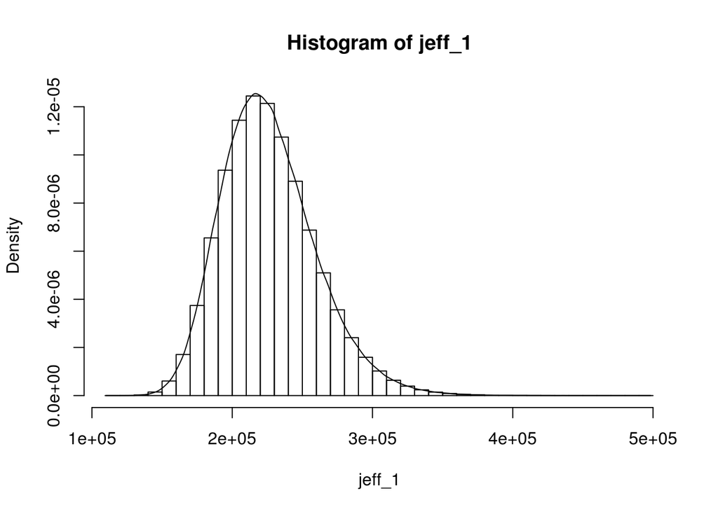

```r
##  Marginal Posterior sigma using Jeffrey's Prior 5(a)

jeff_1 <- rinvgamma(10^6, n_1/2, n_1*var(x1)/2)
hist(jeff_1, freq = FALSE, breaks = 50)
lines(density(jeff_1))
```

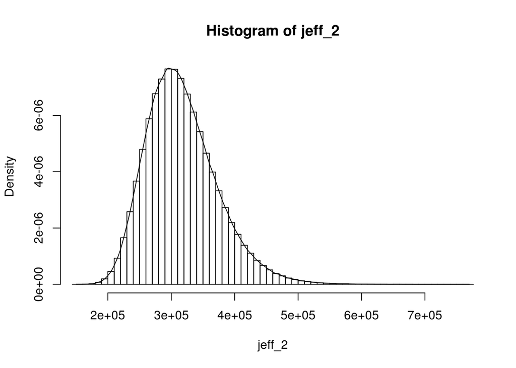

```r
jeff_2 <- rinvgamma(10^6, n_2/2, n_2*var(x2)/2)
hist(jeff_2, freq = FALSE, breaks = 50)
lines(density(jeff_2))
```

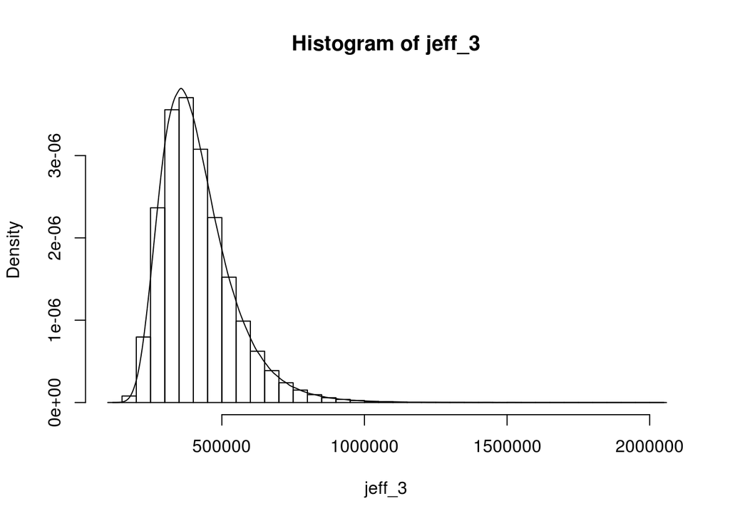

```r
jeff_3 <- rinvgamma(10^6, n_3/2, n_3*var(x3)/2)
hist(jeff_3, freq = FALSE, breaks = 50)
lines(density(jeff_3))
```

Ans.5.b)

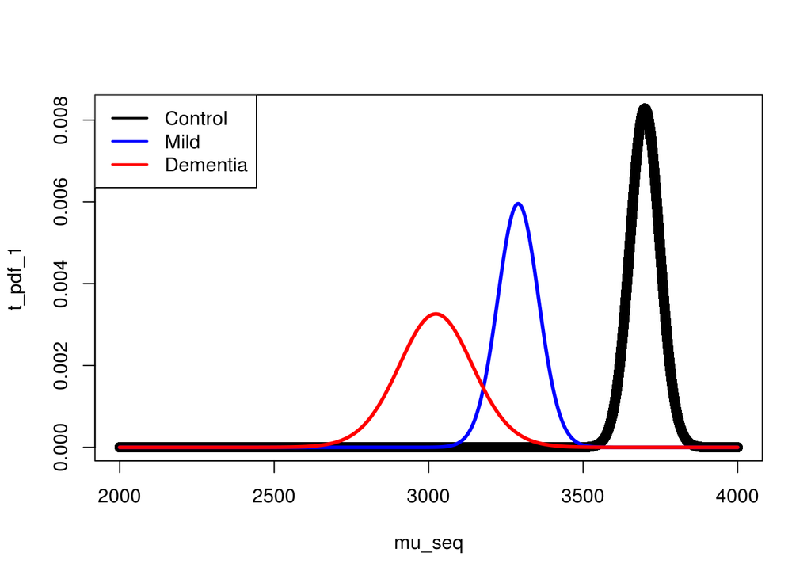

```r
#data group j = 1
#scale_1 = sqrt(var(x1))/n_1
#shift_1 = mean_1
#tVal_1 = rt(10^6, ncp = scale_1+ shift_1, df = n_1-1)

#t_pdf_1 = dt(tVal_1, ncp = scale_1 + shift_1, df = n_1-1)
#plot(tVal_1, t_pdf_1)
#abline(v = mean_1)

#data group j = 2
#scale_2 = sqrt(var(x2))/n_2
#shift_2 = mean_2
#tVal_2 = rt(10^6, ncp = scale_2 + shift_2, df = n_2-1)

#t_pdf_2 = dt(tVal_2, ncp = scale_2 + shift_2, df = n_2-1)
#lines(tVal_2,t_pdf_2,col="red",lwd =3, xlab = expression(mu))
#abline(v = mean_2)

mu_seq = seq(2000,4000, (2000/10^6))

t_pdf_1 =  abs(sqrt(alpha_1 * n_1/beta_1)) * dt(sqrt(alpha_1 * n_1/beta_1) * (mu_seq - mu_1), (2*alpha_1))
plot(mu_seq, t_pdf_1)
t_pdf_2 =  abs(sqrt(alpha_2 * n_2/beta_2)) * dt(sqrt(alpha_2 * n_2/beta_2) * (mu_seq - mu_2), (2*alpha_2))
lines(mu_seq,t_pdf_2,col="blue",lwd =3, xlab = expression(mu))
t_pdf_3 =  abs(sqrt(alpha_3 * n_3/beta_3)) * dt(sqrt(alpha_3 * n_3/beta_3) * (mu_seq - mu_3), (2*alpha_3))
lines(mu_seq,t_pdf_3,col="red",lwd =3, xlab = expression(mu))

legend('topleft', c("Control", "Mild", "Dementia"), col = c("black", "blue", "red"), lwd = 2)
```

Ans.5.c) Conditional Density will be calculated as:

```r
#Samples of sigma taken from posterior for j =1
jeff_sigma_1 <- rinvgamma(10^6, n_1/2, n_1*var(x1)/2)

#Samples of sigma taken from posterior for j =2
jeff_sigma_2 <- rinvgamma(10^6, n_2/2, n_2*var(x2)/2)

#Samples of sigma taken from posterior for j =3
jeff_sigma_3 <- rinvgamma(10^6, n_3/2, n_3*var(x3)/2)

post_jeff_var_512 <- sqrt(jeff_sigma_1/n_1 + jeff_sigma_2/n_2)
post_jeff_var_513 <- sqrt(jeff_sigma_1/n_1 + jeff_sigma_3/n_3)
post_jeff_var_523 <- sqrt(jeff_sigma_2/n_2 + jeff_sigma_3/n_3)

#Mean calculation
jeff_mu_51 = def_mu_n(0, 0,n_1, mean_1 )
jeff_mu_52 = def_mu_n(0, 0,n_2, mean_2 )
jeff_mu_53 = def_mu_n(0, 0,n_3, mean_3 )

post_jeff_mean_512 <- jeff_mu_51 - jeff_mu_52
post_jeff_mean_513 <- jeff_mu_51 - jeff_mu_53
post_jeff_mean_523 <- jeff_mu_52 - jeff_mu_53

d_512 <- rnorm(10^6,  post_jeff_mean_512, post_jeff_var_512)
d_513 <- rnorm(10^6,  post_jeff_mean_513, post_jeff_var_513)
d_523 <- rnorm(10^6,  post_jeff_mean_523, post_jeff_var_523)

pdf_d512 = sum(d_512<0)/10^6
print(pdf_d512)
```

```
## [1] 1e-06
```

```r
pdf_d513 = sum(d_513<0)/10^6
print(pdf_d513)
```

```
## [1] 8e-06
```

```r
pdf_d523 = sum(d_523<0)/10^6
print(pdf_d523)
```

```
## [1] 0.034016
```

Ans.6. This study is same as Q4, with different parameters for the model.
$$\mu_0 = 2133$$
$$\sigma_0 = 279$$
$$n_0 = 127$$
$$\alpha_0 = n_0/2$$
$$\beta_0 = \frac{n_0 \sigma_0^2}{2}$$

```r
lambda_60 = 127
mu_60 = 2133
alpha_60 = 127/2
beta_60 = 127*279^2/2
```

Ans.6.a.) As I have conjugate prior of Normal Inverse Gamma Distribution(N-IG Distribution), my join posterior distribution will also be N-IG distribution with hyper parameters calculated below:

```r
# j=1, Control
mu_61 = def_mu_n(lambda_60, mu_60,n_1, mean_1 )
lambda_61 = def_lambda_n(n_1, lambda_60)
alpha_61 = def_alpha_n(alpha_60, n_1)
beta_61 = def_beta_n(beta_60, x1, mean_1,mu_60, n_1, lambda_60)

# j=2, Mild
mu_62 = def_mu_n(lambda_60, mu_60,n_2, mean_2 )
lambda_62 = def_lambda_n(n_2, lambda_60)
alpha_62 = def_alpha_n(alpha_60, n_2)
beta_62 = def_beta_n(beta_60, x2, mean_2,mu_60, n_2, lambda_60)

# j=3, Dementia
mu_63 = def_mu_n(lambda_60, mu_60,n_3, mean_3 )
lambda_63 = def_lambda_n(n_3, lambda_60)
alpha_63 = def_alpha_n(alpha_60, n_3)
beta_63 = def_beta_n(beta_60, x3, mean_3,mu_60, n_3, lambda_60)
```

Marginal Posterior of $P(\sigma_j^2|y_{i,j}) \sim IG(alpha_n,beta_n)$

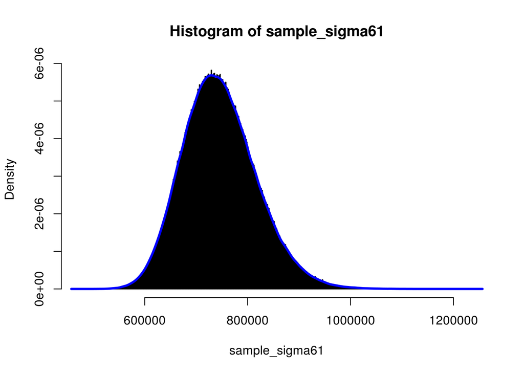

```r
sample_sigma61 <- rinvgamma(10^6, alpha_61, beta_61)
hist(sample_sigma61, freq=FALSE, breaks = 1000)
lines(density(sample_sigma61),col="blue",lwd =3, xlab = expression(sigma^2))
```

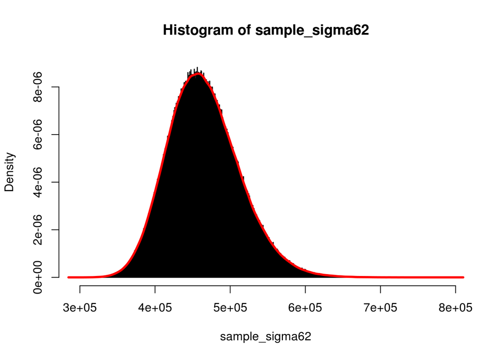

```r
sample_sigma62 <- rinvgamma(10^6, alpha_62, beta_62)
hist(sample_sigma62, freq=FALSE, breaks = 1006)
lines(density(sample_sigma62),col="red",lwd =3, xlab = expression(sigma^2))
```

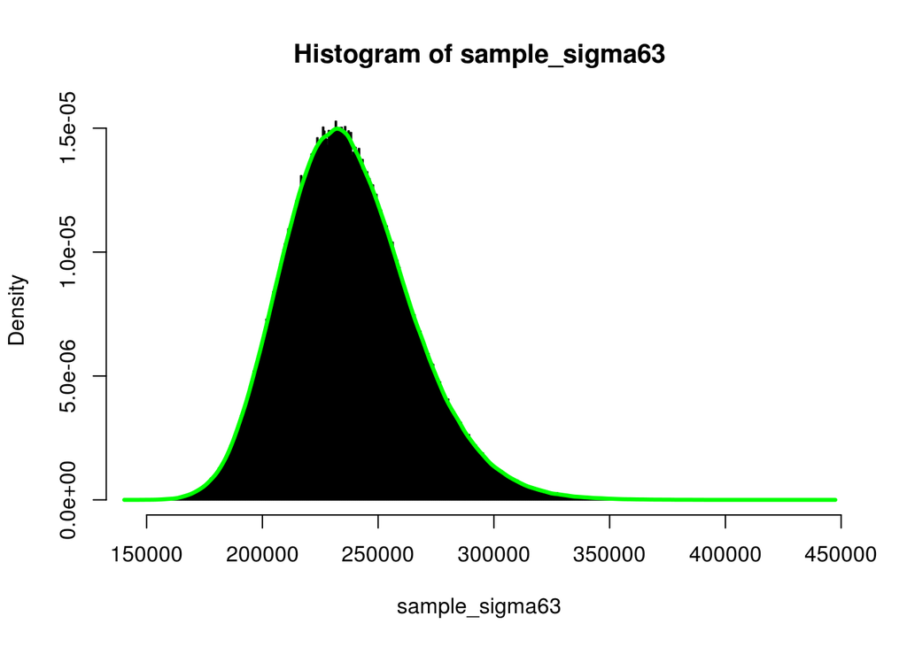

```r
sample_sigma63 <- rinvgamma(10^6, alpha_63, beta_63)
hist(sample_sigma63, freq=FALSE, breaks = 1000)
lines(density(sample_sigma63),col="green",lwd =3, xlab = expression(sigma^2))
```

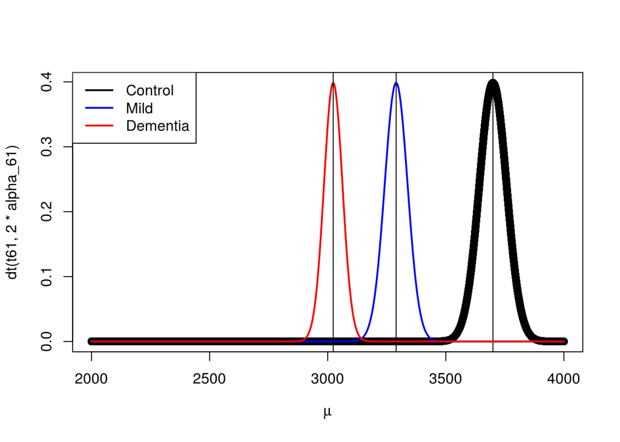

```r
mu_seq = seq(2000,4000, (1500/10^6))

t61 = sqrt(alpha_61*lambda_61/beta_61)*(mu_seq-mean_1)
plot(mu_seq,dt(t61, 2*alpha_61), xlab = expression(mu))
abline(v = mean_1)

t62 = sqrt(alpha_62*lambda_62/beta_62)*(mu_seq-mean_2)
lines(mu_seq, dt(t62, 2*alpha_62), col= "blue",lwd =2, xlab = expression(mu))
abline(v = mean_2)

t63 = sqrt(alpha_63*lambda_63/beta_63)*(mu_seq-mean_3)
lines(mu_seq, dt(t63, 2*alpha_63), col= "red",lwd =2, xlab = expression(mu))
abline(v = mean_3)

legend('topleft', c("Control", "Mild", "Dementia"), col = c("black", "blue", "red"), lwd = 2)
```

Ans.6.c) Conditional density:

```r
sig_samp_61 <- rinvgamma(10^6, alpha_61, beta_61)
sig_samp_62 <- rinvgamma(10^6, alpha_62, beta_62)
sig_samp_63 <- rinvgamma(10^6, alpha_63, beta_63)

post_var_612 <- sqrt(sig_samp_61/n_1 + sig_samp_62/n_2)
post_var_613 <- sqrt(sig_samp_61/n_1 + sig_samp_63/n_3)
post_var_623 <- sqrt(sig_samp_62/n_2 + sig_samp_63/n_3)

post_mean_612 <- mu_61 - mu_62
post_mean_613 <- mu_61 - mu_63
post_mean_623 <- mu_62 - mu_63

d_612 <- rnorm(10^6,  post_mean_612, post_var_612)
d_613 <- rnorm(10^6,  post_mean_613, post_var_613)
d_623 <- rnorm(10^6,  post_mean_623, post_var_623)

n = 10^6
pdf_d612 = sum(d_612<0)/n
print(pdf_d612)
```

```
## [1] 0.01382
```

```r
pdf_d613 = sum(d_613<0)/n
print(pdf_d613)
```

```
## [1] 3e-05
```

```r
pdf_d623 = sum(d_623<0)/n
print(pdf_d623)
```

```
## [1] 0.022356
```

In the initial $4^{th}$ question, our parameters were almost 0, hence the subsiquent information is affected by the initial parameters. This changes in result shows the effect of prior on the data analysis.